# Risk Factor Analysis

## Outcome Variable

**Outcome Variable:** y_rate_haz

## Predictor Variables

**Intervention Variable:** predexfd6

**Adjustment Set:**

unadjusted

## Stratifying Variables

The analysis was stratified on these variable(s):

- agecat
- studyid
- country

## Data Summary

| agecat | studyid | country | predexfd6 | n_cell | n |
| --- | --- | --- | --- | --- | --- |
| 0-3 months | ki0047075b-MAL-ED | BANGLADESH | 1 | 82 | 227 |
| 0-3 months | ki0047075b-MAL-ED | BANGLADESH | 0 | 145 | 227 |
| 0-3 months | ki0047075b-MAL-ED | BRAZIL | 1 | 21 | 163 |
| 0-3 months | ki0047075b-MAL-ED | BRAZIL | 0 | 142 | 163 |
| 0-3 months | ki0047075b-MAL-ED | INDIA | 1 | 8 | 167 |
| 0-3 months | ki0047075b-MAL-ED | INDIA | 0 | 159 | 167 |
| 0-3 months | ki0047075b-MAL-ED | NEPAL | 1 | 11 | 145 |
| 0-3 months | ki0047075b-MAL-ED | NEPAL | 0 | 134 | 145 |
| 0-3 months | ki0047075b-MAL-ED | PERU | 1 | 85 | 254 |
| 0-3 months | ki0047075b-MAL-ED | PERU | 0 | 169 | 254 |
| 0-3 months | ki0047075b-MAL-ED | SOUTH AFRICA | 1 | 2 | 186 |
| 0-3 months | ki0047075b-MAL-ED | SOUTH AFRICA | 0 | 184 | 186 |
| 0-3 months | ki0047075b-MAL-ED | TANZANIA, UNITED REPUBLIC OF | 1 | 0 | 211 |
| 0-3 months | ki0047075b-MAL-ED | TANZANIA, UNITED REPUBLIC OF | 0 | 211 | 211 |
| 0-3 months | ki1000108-CMC-V-BCS-2002 | INDIA | 1 | 6 | 6 |
| 0-3 months | ki1000108-CMC-V-BCS-2002 | INDIA | 0 | 0 | 6 |
| 0-3 months | ki1000108-IRC | INDIA | 1 | 0 | 14 |
| 0-3 months | ki1000108-IRC | INDIA | 0 | 14 | 14 |
| 0-3 months | ki1000109-EE | PAKISTAN | 1 | 33 | 37 |
| 0-3 months | ki1000109-EE | PAKISTAN | 0 | 4 | 37 |
| 0-3 months | ki1000304b-SAS-CompFeed | INDIA | 1 | 104 | 114 |
| 0-3 months | ki1000304b-SAS-CompFeed | INDIA | 0 | 10 | 114 |
| 0-3 months | ki1017093b-PROVIDE | BANGLADESH | 1 | 159 | 640 |
| 0-3 months | ki1017093b-PROVIDE | BANGLADESH | 0 | 481 | 640 |
| 0-3 months | ki1101329-Keneba | GAMBIA | 1 | 391 | 1207 |
| 0-3 months | ki1101329-Keneba | GAMBIA | 0 | 816 | 1207 |
| 0-3 months | ki1113344-GMS-Nepal | NEPAL | 1 | 368 | 501 |
| 0-3 months | ki1113344-GMS-Nepal | NEPAL | 0 | 133 | 501 |
| 0-3 months | kiGH5241-JiVitA-3 | BANGLADESH | 1 | 4607 | 5923 |
| 0-3 months | kiGH5241-JiVitA-3 | BANGLADESH | 0 | 1316 | 5923 |

[output cut: 226 more lines]

The following strata were considered:

- agecat: 0-3 months, studyid: ki0047075b-MAL-ED, country: BANGLADESH
- agecat: 0-3 months, studyid: ki0047075b-MAL-ED, country: BRAZIL
- agecat: 0-3 months, studyid: ki0047075b-MAL-ED, country: INDIA
- agecat: 0-3 months, studyid: ki0047075b-MAL-ED, country: NEPAL
- agecat: 0-3 months, studyid: ki0047075b-MAL-ED, country: PERU
- agecat: 0-3 months, studyid: ki0047075b-MAL-ED, country: SOUTH AFRICA
- agecat: 0-3 months, studyid: ki0047075b-MAL-ED, country: TANZANIA, UNITED REPUBLIC OF
- agecat: 0-3 months, studyid: ki1000108-CMC-V-BCS-2002, country: INDIA
- agecat: 0-3 months, studyid: ki1000108-IRC, country: INDIA
- agecat: 0-3 months, studyid: ki1000109-EE, country: PAKISTAN
- agecat: 0-3 months, studyid: ki1000304b-SAS-CompFeed, country: INDIA
- agecat: 0-3 months, studyid: ki1017093b-PROVIDE, country: BANGLADESH
- agecat: 0-3 months, studyid: ki1101329-Keneba, country: GAMBIA
- agecat: 0-3 months, studyid: ki1113344-GMS-Nepal, country: NEPAL
- agecat: 0-3 months, studyid: kiGH5241-JiVitA-3, country: BANGLADESH
- agecat: 0-3 months, studyid: kiGH5241-JiVitA-4, country: BANGLADESH
- agecat: 12-15 months, studyid: ki0047075b-MAL-ED, country: BANGLADESH
- agecat: 12-15 months, studyid: ki0047075b-MAL-ED, country: BRAZIL
- agecat: 12-15 months, studyid: ki0047075b-MAL-ED, country: INDIA
- agecat: 12-15 months, studyid: ki0047075b-MAL-ED, country: NEPAL
- agecat: 12-15 months, studyid: ki0047075b-MAL-ED, country: PERU
- agecat: 12-15 months, studyid: ki0047075b-MAL-ED, country: SOUTH AFRICA
- agecat: 12-15 months, studyid: ki0047075b-MAL-ED, country: TANZANIA, UNITED REPUBLIC OF
- agecat: 12-15 months, studyid: ki1000108-CMC-V-BCS-2002, country: INDIA
- agecat: 12-15 months, studyid: ki1000108-IRC, country: INDIA
- agecat: 12-15 months, studyid: ki1000109-EE, country: PAKISTAN
- agecat: 12-15 months, studyid: ki1000304b-SAS-CompFeed, country: INDIA
- agecat: 12-15 months, studyid: ki1000304b-SAS-FoodSuppl, country: INDIA
- agecat: 12-15 months, studyid: ki1017093b-PROVIDE, country: BANGLADESH
- agecat: 12-15 months, studyid: ki1101329-Keneba, country: GAMBIA
- agecat: 12-15 months, studyid: ki1113344-GMS-Nepal, country: NEPAL
- agecat: 12-15 months, studyid: ki1148112-LCNI-5, country: MALAWI
- agecat: 12-15 months, studyid: kiGH5241-JiVitA-4, country: BANGLADESH
- agecat: 15-18 months, studyid: ki0047075b-MAL-ED, country: BANGLADESH
- agecat: 15-18 months, studyid: ki0047075b-MAL-ED, country: BRAZIL
- agecat: 15-18 months, studyid: ki0047075b-MAL-ED, country: INDIA
- agecat: 15-18 months, studyid: ki0047075b-MAL-ED, country: NEPAL
- agecat: 15-18 months, studyid: ki0047075b-MAL-ED, country: PERU
- agecat: 15-18 months, studyid: ki0047075b-MAL-ED, country: SOUTH AFRICA
- agecat: 15-18 months, studyid: ki0047075b-MAL-ED, country: TANZANIA, UNITED REPUBLIC OF
- agecat: 15-18 months, studyid: ki1000108-CMC-V-BCS-2002, country: INDIA
- agecat: 15-18 months, studyid: ki1000108-IRC, country: INDIA
- agecat: 15-18 months, studyid: ki1000109-EE, country: PAKISTAN
- agecat: 15-18 months, studyid: ki1000304b-SAS-CompFeed, country: INDIA
- agecat: 15-18 months, studyid: ki1000304b-SAS-FoodSuppl, country: INDIA
- agecat: 15-18 months, studyid: ki1017093b-PROVIDE, country: BANGLADESH
- agecat: 15-18 months, studyid: ki1101329-Keneba, country: GAMBIA
- agecat: 15-18 months, studyid: ki1113344-GMS-Nepal, country: NEPAL
- agecat: 15-18 months, studyid: ki1148112-LCNI-5, country: MALAWI
- agecat: 15-18 months, studyid: kiGH5241-JiVitA-4, country: BANGLADESH
- agecat: 18-21 months, studyid: ki0047075b-MAL-ED, country: BANGLADESH
- agecat: 18-21 months, studyid: ki0047075b-MAL-ED, country: BRAZIL
- agecat: 18-21 months, studyid: ki0047075b-MAL-ED, country: INDIA
- agecat: 18-21 months, studyid: ki0047075b-MAL-ED, country: NEPAL
- agecat: 18-21 months, studyid: ki0047075b-MAL-ED, country: PERU
- agecat: 18-21 months, studyid: ki0047075b-MAL-ED, country: SOUTH AFRICA
- agecat: 18-21 months, studyid: ki0047075b-MAL-ED, country: TANZANIA, UNITED REPUBLIC OF
- agecat: 18-21 months, studyid: ki1000108-CMC-V-BCS-2002, country: INDIA
- agecat: 18-21 months, studyid: ki1000108-IRC, country: INDIA
- agecat: 18-21 months, studyid: ki1000109-EE, country: PAKISTAN
- agecat: 18-21 months, studyid: ki1017093b-PROVIDE, country: BANGLADESH
- agecat: 18-21 months, studyid: ki1101329-Keneba, country: GAMBIA
- agecat: 18-21 months, studyid: ki1113344-GMS-Nepal, country: NEPAL
- agecat: 18-21 months, studyid: ki1148112-LCNI-5, country: MALAWI
- agecat: 21-24 months, studyid: ki0047075b-MAL-ED, country: BANGLADESH
- agecat: 21-24 months, studyid: ki0047075b-MAL-ED, country: BRAZIL
- agecat: 21-24 months, studyid: ki0047075b-MAL-ED, country: INDIA
- agecat: 21-24 months, studyid: ki0047075b-MAL-ED, country: NEPAL
- agecat: 21-24 months, studyid: ki0047075b-MAL-ED, country: PERU
- agecat: 21-24 months, studyid: ki0047075b-MAL-ED, country: SOUTH AFRICA
- agecat: 21-24 months, studyid: ki0047075b-MAL-ED, country: TANZANIA, UNITED REPUBLIC OF
- agecat: 21-24 months, studyid: ki1000108-CMC-V-BCS-2002, country: INDIA
- agecat: 21-24 months, studyid: ki1000108-IRC, country: INDIA
- agecat: 21-24 months, studyid: ki1000109-EE, country: PAKISTAN
- agecat: 21-24 months, studyid: ki1017093b-PROVIDE, country: BANGLADESH
- agecat: 21-24 months, studyid: ki1101329-Keneba, country: GAMBIA
- agecat: 21-24 months, studyid: ki1113344-GMS-Nepal, country: NEPAL
- agecat: 21-24 months, studyid: ki1148112-LCNI-5, country: MALAWI
- agecat: 3-6 months, studyid: ki0047075b-MAL-ED, country: BANGLADESH
- agecat: 3-6 months, studyid: ki0047075b-MAL-ED, country: BRAZIL
- agecat: 3-6 months, studyid: ki0047075b-MAL-ED, country: INDIA
- agecat: 3-6 months, studyid: ki0047075b-MAL-ED, country: NEPAL
- agecat: 3-6 months, studyid: ki0047075b-MAL-ED, country: PERU
- agecat: 3-6 months, studyid: ki0047075b-MAL-ED, country: SOUTH AFRICA
- agecat: 3-6 months, studyid: ki0047075b-MAL-ED, country: TANZANIA, UNITED REPUBLIC OF
- agecat: 3-6 months, studyid: ki1000108-CMC-V-BCS-2002, country: INDIA
- agecat: 3-6 months, studyid: ki1000108-IRC, country: INDIA
- agecat: 3-6 months, studyid: ki1000109-EE, country: PAKISTAN
- agecat: 3-6 months, studyid: ki1000304b-SAS-CompFeed, country: INDIA
- agecat: 3-6 months, studyid: ki1017093b-PROVIDE, country: BANGLADESH
- agecat: 3-6 months, studyid: ki1101329-Keneba, country: GAMBIA
- agecat: 3-6 months, studyid: ki1113344-GMS-Nepal, country: NEPAL
- agecat: 3-6 months, studyid: kiGH5241-JiVitA-3, country: BANGLADESH
- agecat: 3-6 months, studyid: kiGH5241-JiVitA-4, country: BANGLADESH
- agecat: 6-9 months, studyid: ki0047075b-MAL-ED, country: BANGLADESH
- agecat: 6-9 months, studyid: ki0047075b-MAL-ED, country: BRAZIL
- agecat: 6-9 months, studyid: ki0047075b-MAL-ED, country: INDIA
- agecat: 6-9 months, studyid: ki0047075b-MAL-ED, country: NEPAL
- agecat: 6-9 months, studyid: ki0047075b-MAL-ED, country: PERU
- agecat: 6-9 months, studyid: ki0047075b-MAL-ED, country: SOUTH AFRICA
- agecat: 6-9 months, studyid: ki0047075b-MAL-ED, country: TANZANIA, UNITED REPUBLIC OF
- agecat: 6-9 months, studyid: ki1000108-CMC-V-BCS-2002, country: INDIA
- agecat: 6-9 months, studyid: ki1000108-IRC, country: INDIA
- agecat: 6-9 months, studyid: ki1000109-EE, country: PAKISTAN
- agecat: 6-9 months, studyid: ki1000304b-SAS-CompFeed, country: INDIA
- agecat: 6-9 months, studyid: ki1000304b-SAS-FoodSuppl, country: INDIA
- agecat: 6-9 months, studyid: ki1017093b-PROVIDE, country: BANGLADESH
- agecat: 6-9 months, studyid: ki1101329-Keneba, country: GAMBIA
- agecat: 6-9 months, studyid: ki1113344-GMS-Nepal, country: NEPAL
- agecat: 6-9 months, studyid: ki1148112-LCNI-5, country: MALAWI
- agecat: 6-9 months, studyid: kiGH5241-JiVitA-4, country: BANGLADESH
- agecat: 9-12 months, studyid: ki0047075b-MAL-ED, country: BANGLADESH
- agecat: 9-12 months, studyid: ki0047075b-MAL-ED, country: BRAZIL
- agecat: 9-12 months, studyid: ki0047075b-MAL-ED, country: INDIA
- agecat: 9-12 months, studyid: ki0047075b-MAL-ED, country: NEPAL
- agecat: 9-12 months, studyid: ki0047075b-MAL-ED, country: PERU
- agecat: 9-12 months, studyid: ki0047075b-MAL-ED, country: SOUTH AFRICA
- agecat: 9-12 months, studyid: ki0047075b-MAL-ED, country: TANZANIA, UNITED REPUBLIC OF
- agecat: 9-12 months, studyid: ki1000108-CMC-V-BCS-2002, country: INDIA
- agecat: 9-12 months, studyid: ki1000108-IRC, country: INDIA
- agecat: 9-12 months, studyid: ki1000109-EE, country: PAKISTAN
- agecat: 9-12 months, studyid: ki1000304b-SAS-CompFeed, country: INDIA
- agecat: 9-12 months, studyid: ki1000304b-SAS-FoodSuppl, country: INDIA
- agecat: 9-12 months, studyid: ki1017093b-PROVIDE, country: BANGLADESH
- agecat: 9-12 months, studyid: ki1101329-Keneba, country: GAMBIA
- agecat: 9-12 months, studyid: ki1113344-GMS-Nepal, country: NEPAL
- agecat: 9-12 months, studyid: ki1148112-LCNI-5, country: MALAWI
- agecat: 9-12 months, studyid: kiGH5241-JiVitA-4, country: BANGLADESH

### Dropped Strata

Some strata were dropped due to rare outcomes:

- agecat: 0-3 months, studyid: ki0047075b-MAL-ED, country: SOUTH AFRICA
- agecat: 0-3 months, studyid: ki0047075b-MAL-ED, country: TANZANIA, UNITED REPUBLIC OF
- agecat: 0-3 months, studyid: ki1000108-CMC-V-BCS-2002, country: INDIA
- agecat: 0-3 months, studyid: ki1000108-IRC, country: INDIA
- agecat: 0-3 months, studyid: ki1000109-EE, country: PAKISTAN
- agecat: 3-6 months, studyid: ki0047075b-MAL-ED, country: SOUTH AFRICA
- agecat: 3-6 months, studyid: ki0047075b-MAL-ED, country: TANZANIA, UNITED REPUBLIC OF
- agecat: 3-6 months, studyid: ki1000108-CMC-V-BCS-2002, country: INDIA
- agecat: 3-6 months, studyid: ki1000108-IRC, country: INDIA
- agecat: 3-6 months, studyid: ki1000109-EE, country: PAKISTAN
- agecat: 6-9 months, studyid: ki0047075b-MAL-ED, country: SOUTH AFRICA
- agecat: 6-9 months, studyid: ki0047075b-MAL-ED, country: TANZANIA, UNITED REPUBLIC OF
- agecat: 6-9 months, studyid: ki1000108-CMC-V-BCS-2002, country: INDIA
- agecat: 6-9 months, studyid: ki1000108-IRC, country: INDIA
- agecat: 6-9 months, studyid: ki1000304b-SAS-FoodSuppl, country: INDIA
- agecat: 9-12 months, studyid: ki0047075b-MAL-ED, country: SOUTH AFRICA
- agecat: 9-12 months, studyid: ki0047075b-MAL-ED, country: TANZANIA, UNITED REPUBLIC OF
- agecat: 9-12 months, studyid: ki1000108-CMC-V-BCS-2002, country: INDIA
- agecat: 9-12 months, studyid: ki1000108-IRC, country: INDIA
- agecat: 9-12 months, studyid: ki1000304b-SAS-FoodSuppl, country: INDIA
- agecat: 12-15 months, studyid: ki0047075b-MAL-ED, country: SOUTH AFRICA
- agecat: 12-15 months, studyid: ki0047075b-MAL-ED, country: TANZANIA, UNITED REPUBLIC OF
- agecat: 12-15 months, studyid: ki1000108-CMC-V-BCS-2002, country: INDIA
- agecat: 12-15 months, studyid: ki1000108-IRC, country: INDIA
- agecat: 12-15 months, studyid: ki1000304b-SAS-CompFeed, country: INDIA
- agecat: 12-15 months, studyid: ki1000304b-SAS-FoodSuppl, country: INDIA
- agecat: 12-15 months, studyid: ki1148112-LCNI-5, country: MALAWI
- agecat: 15-18 months, studyid: ki0047075b-MAL-ED, country: SOUTH AFRICA
- agecat: 15-18 months, studyid: ki0047075b-MAL-ED, country: TANZANIA, UNITED REPUBLIC OF
- agecat: 15-18 months, studyid: ki1000108-CMC-V-BCS-2002, country: INDIA
- agecat: 15-18 months, studyid: ki1000108-IRC, country: INDIA
- agecat: 15-18 months, studyid: ki1000304b-SAS-FoodSuppl, country: INDIA
- agecat: 15-18 months, studyid: ki1148112-LCNI-5, country: MALAWI
- agecat: 18-21 months, studyid: ki0047075b-MAL-ED, country: SOUTH AFRICA
- agecat: 18-21 months, studyid: ki0047075b-MAL-ED, country: TANZANIA, UNITED REPUBLIC OF
- agecat: 18-21 months, studyid: ki1000108-CMC-V-BCS-2002, country: INDIA
- agecat: 18-21 months, studyid: ki1000108-IRC, country: INDIA
- agecat: 21-24 months, studyid: ki0047075b-MAL-ED, country: SOUTH AFRICA
- agecat: 21-24 months, studyid: ki0047075b-MAL-ED, country: TANZANIA, UNITED REPUBLIC OF
- agecat: 21-24 months, studyid: ki1000108-CMC-V-BCS-2002, country: INDIA
- agecat: 21-24 months, studyid: ki1000108-IRC, country: INDIA
- agecat: 21-24 months, studyid: ki1000109-EE, country: PAKISTAN

## Methods Detail

We’re interested in the causal parameters $E[Y_a]$ for all values of $a \in \mathcal{A}$. These parameters represent the mean outcome if, possibly contrary to fact, we intervened to set all units to have $A=a$. Under the randomization and positivity assumptions, these are identified by the statistical parameters $\psi_a=E_W[E_{Y|A,W}(Y|A=a,W)]$. In addition, we’re interested in the mean of $Y$, $E[Y]$ under no intervention (the observed mean). We will estimate these parameters by using SuperLearner to fit the relevant likelihood factors – $E_{Y|A,W}(Y|A=a,W)$ and $p(A=a|W)$, and then updating our likelihood fit using a joint TMLE.

For unadjusted analyses ($W=\{\}$), initial likelihoods were estimated using Lrnr_glm to estimate the simple $E(Y|A)$ and Lrnr_mean to estimate $p(A)$. For adjusted analyses, a small library containing Lrnr_glmnet, Lrnr_xgboost, and Lrnr_mean was used.

Having estimated these parameters, we will then use the delta method to estimate relative risks and attributable risks relative to a prespecified baseline level of $A$.

# Results Detail

## Results Plots

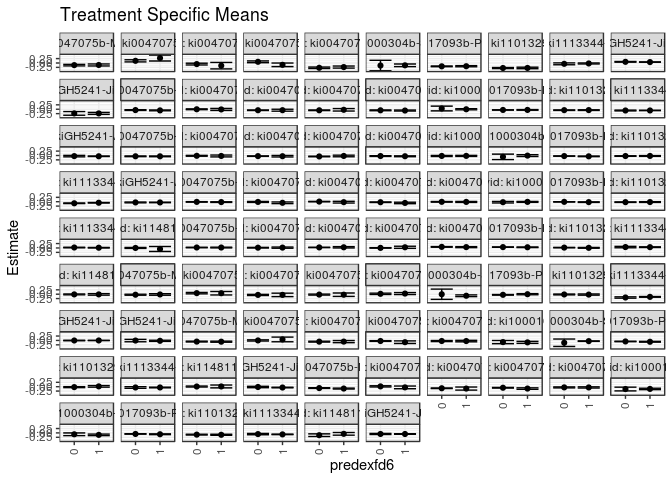

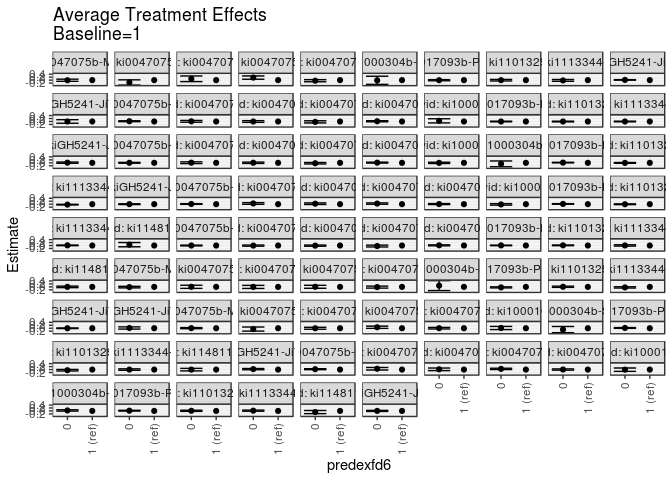

[figure not shown]

## Results Table

### Parameter: TSM

| agecat | studyid | country | intervention_level | baseline_level | estimate | ci_lower | ci_upper |
| --- | --- | --- | --- | --- | --- | --- | --- |
| 0-3 months | ki0047075b-MAL-ED | BANGLADESH | 1 | NA | -0.1131412 | -0.1702073 | -0.0560751 |
| 0-3 months | ki0047075b-MAL-ED | BANGLADESH | 0 | NA | -0.1215017 | -0.1657384 | -0.0772650 |
| 0-3 months | ki0047075b-MAL-ED | BRAZIL | 1 | NA | 0.2823088 | 0.1137025 | 0.4509152 |
| 0-3 months | ki0047075b-MAL-ED | BRAZIL | 0 | NA | 0.1243016 | 0.0638335 | 0.1847696 |
| 0-3 months | ki0047075b-MAL-ED | INDIA | 1 | NA | -0.1519059 | -0.3354979 | 0.0316861 |
| 0-3 months | ki0047075b-MAL-ED | INDIA | 0 | NA | -0.0618553 | -0.1121399 | -0.0115708 |
| 0-3 months | ki0047075b-MAL-ED | NEPAL | 1 | NA | -0.1038581 | -0.2050036 | -0.0027127 |
| 0-3 months | ki0047075b-MAL-ED | NEPAL | 0 | NA | 0.0680400 | 0.0188800 | 0.1172000 |
| 0-3 months | ki0047075b-MAL-ED | PERU | 1 | NA | -0.2320113 | -0.2905818 | -0.1734407 |
| 0-3 months | ki0047075b-MAL-ED | PERU | 0 | NA | -0.2728250 | -0.3139776 | -0.2316725 |
| 0-3 months | ki1000304b-SAS-CompFeed | INDIA | 1 | NA | -0.1324142 | -0.2082792 | -0.0565492 |
| 0-3 months | ki1000304b-SAS-CompFeed | INDIA | 0 | NA | -0.1447300 | -0.4423443 | 0.1528842 |
| 0-3 months | ki1017093b-PROVIDE | BANGLADESH | 1 | NA | -0.1840111 | -0.2158075 | -0.1522146 |
| 0-3 months | ki1017093b-PROVIDE | BANGLADESH | 0 | NA | -0.1893721 | -0.2099562 | -0.1687879 |
| 0-3 months | ki1101329-Keneba | GAMBIA | 1 | NA | -0.2819944 | -0.3245682 | -0.2394206 |
| 0-3 months | ki1101329-Keneba | GAMBIA | 0 | NA | -0.2864323 | -0.3168345 | -0.2560300 |
| 0-3 months | ki1113344-GMS-Nepal | NEPAL | 1 | NA | -0.0266193 | -0.0555083 | 0.0022697 |
| 0-3 months | ki1113344-GMS-Nepal | NEPAL | 0 | NA | -0.0468944 | -0.1000574 | 0.0062686 |
| 0-3 months | kiGH5241-JiVitA-3 | BANGLADESH | 1 | NA | 0.0519741 | 0.0424029 | 0.0615453 |
| 0-3 months | kiGH5241-JiVitA-3 | BANGLADESH | 0 | NA | 0.0664319 | 0.0489169 | 0.0839469 |
| 0-3 months | kiGH5241-JiVitA-4 | BANGLADESH | 1 | NA | -0.2372989 | -0.2925925 | -0.1820053 |
| 0-3 months | kiGH5241-JiVitA-4 | BANGLADESH | 0 | NA | -0.2370355 | -0.3426502 | -0.1314208 |
| 3-6 months | ki0047075b-MAL-ED | BANGLADESH | 1 | NA | -0.0146307 | -0.0573361 | 0.0280748 |
| 3-6 months | ki0047075b-MAL-ED | BANGLADESH | 0 | NA | -0.0296908 | -0.0585814 | -0.0008003 |
| 3-6 months | ki0047075b-MAL-ED | BRAZIL | 1 | NA | 0.0559017 | -0.0431717 | 0.1549751 |
| 3-6 months | ki0047075b-MAL-ED | BRAZIL | 0 | NA | 0.0603742 | 0.0210929 | 0.0996556 |
| 3-6 months | ki0047075b-MAL-ED | INDIA | 1 | NA | -0.0390217 | -0.1372314 | 0.0591880 |
| 3-6 months | ki0047075b-MAL-ED | INDIA | 0 | NA | -0.0403537 | -0.0722876 | -0.0084197 |
| 3-6 months | ki0047075b-MAL-ED | NEPAL | 1 | NA | -0.0285846 | -0.1253420 | 0.0681728 |
| 3-6 months | ki0047075b-MAL-ED | NEPAL | 0 | NA | -0.0215975 | -0.0501274 | 0.0069324 |

[output cut: 142 more lines]

### Parameter: E(Y)

| agecat | studyid | country | intervention_level | baseline_level | estimate | ci_lower | ci_upper |
| --- | --- | --- | --- | --- | --- | --- | --- |
| 0-3 months | ki0047075b-MAL-ED | BANGLADESH | NA | NA | -0.1184816 | -0.1534627 | -0.0835006 |
| 0-3 months | ki0047075b-MAL-ED | BRAZIL | NA | NA | 0.1446583 | 0.0870976 | 0.2022191 |
| 0-3 months | ki0047075b-MAL-ED | INDIA | NA | NA | -0.0661691 | -0.1149338 | -0.0174045 |
| 0-3 months | ki0047075b-MAL-ED | NEPAL | NA | NA | 0.0549995 | 0.0083296 | 0.1016694 |
| 0-3 months | ki0047075b-MAL-ED | PERU | NA | NA | -0.2591669 | -0.2929238 | -0.2254100 |
| 0-3 months | ki1000304b-SAS-CompFeed | INDIA | NA | NA | -0.1334945 | -0.2172486 | -0.0497405 |
| 0-3 months | ki1017093b-PROVIDE | BANGLADESH | NA | NA | -0.1880402 | -0.2054115 | -0.1706689 |
| 0-3 months | ki1101329-Keneba | GAMBIA | NA | NA | -0.2849946 | -0.3097468 | -0.2602425 |
| 0-3 months | ki1113344-GMS-Nepal | NEPAL | NA | NA | -0.0320017 | -0.0574984 | -0.0065051 |
| 0-3 months | kiGH5241-JiVitA-3 | BANGLADESH | NA | NA | 0.0551864 | 0.0461861 | 0.0641867 |
| 0-3 months | kiGH5241-JiVitA-4 | BANGLADESH | NA | NA | -0.2372614 | -0.2869744 | -0.1875485 |
| 3-6 months | ki0047075b-MAL-ED | BANGLADESH | NA | NA | -0.0242637 | -0.0483310 | -0.0001965 |
| 3-6 months | ki0047075b-MAL-ED | BRAZIL | NA | NA | 0.0597292 | 0.0232017 | 0.0962566 |
| 3-6 months | ki0047075b-MAL-ED | INDIA | NA | NA | -0.0402849 | -0.0709914 | -0.0095783 |
| 3-6 months | ki0047075b-MAL-ED | NEPAL | NA | NA | -0.0219437 | -0.0494813 | 0.0055938 |
| 3-6 months | ki0047075b-MAL-ED | PERU | NA | NA | 0.0265214 | -0.0048238 | 0.0578666 |
| 3-6 months | ki1000304b-SAS-CompFeed | INDIA | NA | NA | -0.0800769 | -0.0985661 | -0.0615877 |
| 3-6 months | ki1017093b-PROVIDE | BANGLADESH | NA | NA | -0.0269625 | -0.0428628 | -0.0110622 |
| 3-6 months | ki1101329-Keneba | GAMBIA | NA | NA | -0.0174002 | -0.0363928 | 0.0015925 |
| 3-6 months | ki1113344-GMS-Nepal | NEPAL | NA | NA | -0.1617717 | -0.1805409 | -0.1430025 |
| 3-6 months | kiGH5241-JiVitA-3 | BANGLADESH | NA | NA | -0.0021434 | -0.0106005 | 0.0063136 |
| 3-6 months | kiGH5241-JiVitA-4 | BANGLADESH | NA | NA | -0.0191699 | -0.0487030 | 0.0103631 |
| 6-9 months | ki0047075b-MAL-ED | BANGLADESH | NA | NA | -0.0677541 | -0.0853832 | -0.0501249 |
| 6-9 months | ki0047075b-MAL-ED | BRAZIL | NA | NA | 0.0087834 | -0.0260798 | 0.0436466 |
| 6-9 months | ki0047075b-MAL-ED | INDIA | NA | NA | -0.0688970 | -0.0921281 | -0.0456658 |
| 6-9 months | ki0047075b-MAL-ED | NEPAL | NA | NA | -0.0368585 | -0.0562650 | -0.0174521 |
| 6-9 months | ki0047075b-MAL-ED | PERU | NA | NA | -0.0335784 | -0.0576919 | -0.0094649 |
| 6-9 months | ki1000109-EE | PAKISTAN | NA | NA | -0.1084252 | -0.1595142 | -0.0573361 |
| 6-9 months | ki1000304b-SAS-CompFeed | INDIA | NA | NA | -0.0484569 | -0.0689491 | -0.0279646 |
| 6-9 months | ki1017093b-PROVIDE | BANGLADESH | NA | NA | -0.0614264 | -0.0722690 | -0.0505838 |

[output cut: 56 more lines]

### Parameter: ATE

| agecat | studyid | country | intervention_level | baseline_level | estimate | ci_lower | ci_upper |
| --- | --- | --- | --- | --- | --- | --- | --- |
| 0-3 months | ki0047075b-MAL-ED | BANGLADESH | 1 | 1 | 0.0000000 | 0.0000000 | 0.0000000 |
| 0-3 months | ki0047075b-MAL-ED | BANGLADESH | 0 | 1 | -0.0083605 | -0.0805645 | 0.0638436 |
| 0-3 months | ki0047075b-MAL-ED | BRAZIL | 1 | 1 | 0.0000000 | 0.0000000 | 0.0000000 |
| 0-3 months | ki0047075b-MAL-ED | BRAZIL | 0 | 1 | -0.1580073 | -0.3371287 | 0.0211141 |
| 0-3 months | ki0047075b-MAL-ED | INDIA | 1 | 1 | 0.0000000 | 0.0000000 | 0.0000000 |
| 0-3 months | ki0047075b-MAL-ED | INDIA | 0 | 1 | 0.0900506 | -0.1003032 | 0.2804044 |
| 0-3 months | ki0047075b-MAL-ED | NEPAL | 1 | 1 | 0.0000000 | 0.0000000 | 0.0000000 |
| 0-3 months | ki0047075b-MAL-ED | NEPAL | 0 | 1 | 0.1718981 | 0.0594388 | 0.2843575 |
| 0-3 months | ki0047075b-MAL-ED | PERU | 1 | 1 | 0.0000000 | 0.0000000 | 0.0000000 |
| 0-3 months | ki0047075b-MAL-ED | PERU | 0 | 1 | -0.0408138 | -0.1123962 | 0.0307687 |
| 0-3 months | ki1000304b-SAS-CompFeed | INDIA | 1 | 1 | 0.0000000 | 0.0000000 | 0.0000000 |
| 0-3 months | ki1000304b-SAS-CompFeed | INDIA | 0 | 1 | -0.0123158 | -0.2878387 | 0.2632071 |
| 0-3 months | ki1017093b-PROVIDE | BANGLADESH | 1 | 1 | 0.0000000 | 0.0000000 | 0.0000000 |
| 0-3 months | ki1017093b-PROVIDE | BANGLADESH | 0 | 1 | -0.0053610 | -0.0432388 | 0.0325167 |
| 0-3 months | ki1101329-Keneba | GAMBIA | 1 | 1 | 0.0000000 | 0.0000000 | 0.0000000 |
| 0-3 months | ki1101329-Keneba | GAMBIA | 0 | 1 | -0.0044379 | -0.0567525 | 0.0478768 |
| 0-3 months | ki1113344-GMS-Nepal | NEPAL | 1 | 1 | 0.0000000 | 0.0000000 | 0.0000000 |
| 0-3 months | ki1113344-GMS-Nepal | NEPAL | 0 | 1 | -0.0202751 | -0.0807803 | 0.0402301 |
| 0-3 months | kiGH5241-JiVitA-3 | BANGLADESH | 1 | 1 | 0.0000000 | 0.0000000 | 0.0000000 |
| 0-3 months | kiGH5241-JiVitA-3 | BANGLADESH | 0 | 1 | 0.0144578 | -0.0039212 | 0.0328367 |
| 0-3 months | kiGH5241-JiVitA-4 | BANGLADESH | 1 | 1 | 0.0000000 | 0.0000000 | 0.0000000 |
| 0-3 months | kiGH5241-JiVitA-4 | BANGLADESH | 0 | 1 | 0.0002634 | -0.1190837 | 0.1196105 |
| 3-6 months | ki0047075b-MAL-ED | BANGLADESH | 1 | 1 | 0.0000000 | 0.0000000 | 0.0000000 |
| 3-6 months | ki0047075b-MAL-ED | BANGLADESH | 0 | 1 | -0.0150602 | -0.0666200 | 0.0364997 |
| 3-6 months | ki0047075b-MAL-ED | BRAZIL | 1 | 1 | 0.0000000 | 0.0000000 | 0.0000000 |
| 3-6 months | ki0047075b-MAL-ED | BRAZIL | 0 | 1 | 0.0044725 | -0.1021040 | 0.1110491 |
| 3-6 months | ki0047075b-MAL-ED | INDIA | 1 | 1 | 0.0000000 | 0.0000000 | 0.0000000 |
| 3-6 months | ki0047075b-MAL-ED | INDIA | 0 | 1 | -0.0013320 | -0.1046030 | 0.1019391 |
| 3-6 months | ki0047075b-MAL-ED | NEPAL | 1 | 1 | 0.0000000 | 0.0000000 | 0.0000000 |
| 3-6 months | ki0047075b-MAL-ED | NEPAL | 0 | 1 | 0.0069871 | -0.0938888 | 0.1078630 |

[output cut: 142 more lines]

### Parameter: PAR

| agecat | studyid | country | intervention_level | baseline_level | estimate | ci_lower | ci_upper |
| --- | --- | --- | --- | --- | --- | --- | --- |
| 0-3 months | ki0047075b-MAL-ED | BANGLADESH | 1 | NA | -0.0053404 | -0.0514649 | 0.0407841 |
| 0-3 months | ki0047075b-MAL-ED | BRAZIL | 1 | NA | -0.1376505 | -0.2939077 | 0.0186067 |
| 0-3 months | ki0047075b-MAL-ED | INDIA | 1 | NA | 0.0857368 | -0.0955219 | 0.2669954 |
| 0-3 months | ki0047075b-MAL-ED | NEPAL | 1 | NA | 0.1588576 | 0.0546641 | 0.2630511 |
| 0-3 months | ki0047075b-MAL-ED | PERU | 1 | NA | -0.0271556 | -0.0748424 | 0.0205311 |
| 0-3 months | ki1000304b-SAS-CompFeed | INDIA | 1 | NA | -0.0010803 | -0.0255707 | 0.0234100 |
| 0-3 months | ki1017093b-PROVIDE | BANGLADESH | 1 | NA | -0.0040291 | -0.0324972 | 0.0244389 |
| 0-3 months | ki1101329-Keneba | GAMBIA | 1 | NA | -0.0030003 | -0.0383681 | 0.0323676 |
| 0-3 months | ki1113344-GMS-Nepal | NEPAL | 1 | NA | -0.0053824 | -0.0214638 | 0.0106990 |
| 0-3 months | kiGH5241-JiVitA-3 | BANGLADESH | 1 | NA | 0.0032123 | -0.0008644 | 0.0072890 |
| 0-3 months | kiGH5241-JiVitA-4 | BANGLADESH | 1 | NA | 0.0000374 | -0.0169312 | 0.0170061 |
| 3-6 months | ki0047075b-MAL-ED | BANGLADESH | 1 | NA | -0.0096331 | -0.0426266 | 0.0233604 |
| 3-6 months | ki0047075b-MAL-ED | BRAZIL | 1 | NA | 0.0038274 | -0.0873777 | 0.0950326 |
| 3-6 months | ki0047075b-MAL-ED | INDIA | 1 | NA | -0.0012632 | -0.0992010 | 0.0966747 |
| 3-6 months | ki0047075b-MAL-ED | NEPAL | 1 | NA | 0.0066409 | -0.0892369 | 0.1025187 |
| 3-6 months | ki0047075b-MAL-ED | PERU | 1 | NA | -0.0099769 | -0.0546251 | 0.0346713 |
| 3-6 months | ki1000304b-SAS-CompFeed | INDIA | 1 | NA | 0.0086294 | -0.0278325 | 0.0450912 |
| 3-6 months | ki1017093b-PROVIDE | BANGLADESH | 1 | NA | -0.0264737 | -0.0542470 | 0.0012996 |
| 3-6 months | ki1101329-Keneba | GAMBIA | 1 | NA | 0.0049712 | -0.0241639 | 0.0341062 |
| 3-6 months | ki1113344-GMS-Nepal | NEPAL | 1 | NA | -0.0098880 | -0.0218068 | 0.0020308 |
| 3-6 months | kiGH5241-JiVitA-3 | BANGLADESH | 1 | NA | -0.0003772 | -0.0046460 | 0.0038916 |
| 3-6 months | kiGH5241-JiVitA-4 | BANGLADESH | 1 | NA | 0.0021585 | -0.0087261 | 0.0130431 |
| 6-9 months | ki0047075b-MAL-ED | BANGLADESH | 1 | NA | 0.0037057 | -0.0197920 | 0.0272034 |
| 6-9 months | ki0047075b-MAL-ED | BRAZIL | 1 | NA | -0.0487365 | -0.1653979 | 0.0679248 |
| 6-9 months | ki0047075b-MAL-ED | INDIA | 1 | NA | -0.0027803 | -0.0647284 | 0.0591677 |
| 6-9 months | ki0047075b-MAL-ED | NEPAL | 1 | NA | 0.0620028 | -0.0103395 | 0.1343450 |
| 6-9 months | ki0047075b-MAL-ED | PERU | 1 | NA | 0.0012528 | -0.0320709 | 0.0345765 |
| 6-9 months | ki1000109-EE | PAKISTAN | 1 | NA | 0.0018109 | -0.0100293 | 0.0136512 |
| 6-9 months | ki1000304b-SAS-CompFeed | INDIA | 1 | NA | -0.0082043 | -0.0263761 | 0.0099674 |
| 6-9 months | ki1017093b-PROVIDE | BANGLADESH | 1 | NA | 0.0145424 | -0.0054137 | 0.0344985 |

[output cut: 56 more lines]